$$\huge \text{Rapport du projet d'Algorithmique et structures de données.}$$

# Introduction.

Dans ce rapport nous détaillerons les différents algorithmes qu'on a implémenté pour résoudre le problème de la recherche du nombre de points dans chaque composante connexe d'un graphe non orienté. En particulier, nous allons expliciter la complexité temporelle de chaque algorithme et les entrées sur lesquelles ils fonctionnent efficacement en visualisant ces effets à l'aide de courbes de performance pour pouvoir comparer leurs performances sur différentes entrées. Enfin, nous discuterons de quelques points d'amélioration de notre dernier algorithme.

# Analyse des algorithmes

### I. Algorithme Depth-First-Search:

```python
def print_components_sizes(distance, points):
    """
    affichage des tailles triees de chaque composante
    """
    hash_map = {}
    visited_map = {}
    liste_taille = []
    for point in points:
        hash_map[point] = []
        visited_map[point] = False
        for voisin in points:
            if voisin != point and est_proche(distance, point, voisin):
                hash_map[point].append(voisin)
    for point in points:
        if not visited_map[point]:
            taille = 1
            visited_map[point] = True
            pile = [point]
            visited = [point]
            while pile:
                parent = pile.pop()
                for element in hash_map[parent]:
                    if element not in visited:
                        pile.append(element)
                        visited.append(element)
                        visited_map[element] = True
                        taille += 1
            liste_taille.append(taille)
    liste_taille.sort(reverse=True)
    print(f"{liste_taille}")
```

Le code ci-dessus est l'implémentation en python de notre algorithme.  
Dans cet algorithme, la construction du graphe (en utilisant hash_map) coûte dans tous les cas $O\left(n^2\right).$  
Soit n le nombre de points, et E le nombre d'arêtes dans le graphe. Le coût de recherche des composantes connexes est de $O(n+E)$.

1. Meilleur cas

Le meilleur cas représente le cas où il n'y a pas d'arêtes dans le graphe, c'est-à-dire que tous les points sont isolés $(E = 0)$. Dans ce cas, chaque point représente une composante connexe dans le graphe. Le coût est donc dominé par la construction du graphe. La complexité de l'algorithme est $O\left(n^2\right)$. 2. Pire cas Le pire cas représente le cas où le graphe est complet. Dans ce cas $E \ = \frac{n\,(n-1)}{2}$, et la `liste_taille` contient un seul élément. Ainsi la complexité temporelle est $O\left(2\,n^2 + n\right)$. 3. Coût moyen Le calcul du coût moyen est très difficile sans savoir la distribution des points dans le plan, ou celle des arêtes dans le graphe. L'expression génerale du coût moyen reste dépendante de E, et on peut l'écrire: $O\left(n^2 + n + E + m\,log(m)\right)$ avec m le nombre de composantes connexes.

### II.Structure Union-Find

L'algorithme Union-Find est une structure de données qui permet de gérer des ensembles disjoints et est particulièrement utile pour les problèmes de connectivité dans les graphes.  
L'idée donc est d'avoir un point représentant pour chaque composante connexe et de stocker la taille de la composante dont ce point est le représentant.  
On a initialisé une liste de classes `class_liste`, où chaque point est considéré comme une classe distincte (un singleton) au début. Il y a donc n classes, où n est le nombre de points, ensuite on parcourt chaque paire de points distincts dans la liste des points. Pour chaque paire de points, on vérifie s'ils sont voisins. On utilise donc une fonction `find` pour remonter au représentants des composantes connexes auquelles appartiennent les deux points considérés. Après, il ne reste que fusionner ces deux classes.

```python
def find(parents, point):
    """Trouver la classe d'un point"""
    if parents[point] != point:
        parents[point] = find(parents, parents[point])
    return parents[point]

def union(parents, sizes, point1, point2):
    """Union two components in the union-find data structure"""
    parent_1 = find(parents, point1)
    parent_2 = find(parents, point2)
    if parent_1 != parent_2:
        if sizes[parent_1] < sizes[parent_2]:
            parent_1, parent_2 = parent_2, parent_1
        parents[parent_2] = parent_1
        sizes[parent_1] += sizes[parent_2]

def print_components_sizes(distance, points):
    """
    affichage des tailles triees de chaque composante
    """
    num_points = len(points)
    parents = list(range(num_points))
    sizes = [1] * num_points
    for i in range(1, num_points):
        for j in range(i):
            if points[i].distance_to(points[j]) <= distance:
                union(parents, sizes, i, j)
    class_sizes = {}
    for i in range(num_points):
        parent = find(parents, i)
        if parent not in class_sizes:
            class_sizes[parent] = 0
        class_sizes[parent] += 1
    class_list = list(class_sizes.values())
    class_list.sort(reverse=True)
    print(f"{class_list}")
```

La complexité globale de l'algorithme est donc dominée par la boucle double et le tri, ce qui donne une complexité de $O(n^2\,\alpha(n) + m\,log(m))$. Dans le *cas moyen* et le *pire cas*, la complexité est généralement dominée par le terme $O(n^2\,\alpha(n))$, car le nombre de points peut être suffisamment grand pour que le terme $m\,log(m)$ devienne négligeable par rapport à $n^2\,\alpha(n).$

Dans *le meilleur des cas*, si tous les points sont isolés, alors la boucle double ne ferait aucune union. Toutefois, elle vérifierait toujours toutes les paires de points, ce qui représente $O(n^2)$ paires de points.  
Ainsi, la complexité pour le meilleur cas serait dominée par la boucle double, et le tri :$O(n^2)$ pour la boucle double et $O(n\,log(n))$ pour le tri. La complexité globale du meilleur cas serait donc $O(n^2 + n\,log(n))$, qui est dominée par $O(n^2)$.

### III. Structure Grid

L'idée principale de cet algorithme est de minimiser le nombre de points qu'on verifie à chaque étape d'union. On répartie le plan donc sous forme d'une grille de cellules de même taille (dans ce cas côté = `distance`).  
La fonction `coord_cell` calcule les coordonnées de la cellule à laquelle appartient un point dans la grille. Chaque point est placé dans une cellule en fonction de ses coordonnées.  
La fonction `build_grid` construit la grille en ajoutant les points dans leurs cellules correspondantes. Cette structure de données facilite la recherche des points voisins d'un point donné.  
La fonction `implement_union_find` construit la structure de données Union-Find pour trouver les composantes connectées parmi les points en fonction de la distance spécifiée. Elle commence par construire la grille, puis parcourt chaque cellule de la grille et ses cellules adjacentes pour vérifier si les points sont proches les uns des autres. Si deux points sont proches, ils sont unis dans la structure Union-Find.

```python
def coord_cell(point, distance):
    """
    Given a point and distance,
    calculates the coordinates of the cell that the point belongs to in the grid.
    """
    abscisse = int(point.coordinates[0] // distance)
    ordonnee = int(point.coordinates[1] // distance)
    return abscisse, ordonnee


def build_grid(distance, points):
    """
    Constructs the grid data structure
    by putting points into their corresponding cells.
    """
    grid = {}
    for idx, point in enumerate(points):
        cell = coord_cell(point, distance)
        if cell not in grid:
            grid[cell] = set()
        grid[cell].add(idx)
    return grid

def implement_union_find(distance, points):
    """
    Given the list of points and the distance threshold,
    constructs and returns the Union-Find data structure
    to efficiently find connected components among the points
    based on the specified distance.
    """
    parents = list(range(len(points)))
    ranks = [0] * len(points)
    grid = build_grid(distance, points)

    for cell, point_indexes in grid.items():
        adj_cells = [
            (cell[0] + dx, cell[1] + dy) for dx in range(-1, 2)
            for dy in range(-1, 2)
        ]

        for idx in point_indexes:
            for adj_cell in adj_cells:
                if adj_cell in grid:
                    for j in grid[adj_cell]:
                        if idx != j and points[idx].distance_to(points[j]) <= distance:
                            union(parents, ranks, idx, j)

    return parents
```

Le but donc est de ne parcourir que les points dans les cellules adjacentes à un point au lieu de parcourir tous le points du graphe à chaque fois.  
La complexité de cet algorithme dépend des entrées, le nombre de points n, et la distance seuil d, qui contrôlent la densité du graphe.  
La fonction `coord_cell` a une complexité temporelle constante, car elle effectue un calcul simple pour déterminer les coordonnées de la cellule à laquelle appartient un point.  
La fonction `build_grid` a une complexité temporelle en $O(n)$, puisqu'elle parcourt tous les points une fois et effectue un travail constant pour chaque point en les ajoutant à la grille.  
Pour la fonction `implement_union_find` la complexité dépend du nombre de points n, de la distance seuil d. Dans *le pire des cas*, tous les points sont proches les uns des autres, et la complexité temporelle est dominée par la recherche des voisins pour chaque point qui sera de l'ordre de $O(n^2\,\alpha(n))$. *En moyenne*, la complexité est beaucoup plus faible en raison de la structure de grille qui réduit considérablement le nombre de comparaisons de distances à effectuer.  
*Le meilleur cas* se produit encore lorsque les points sont suffisamment éloignés les uns des autres, de sorte qu'aucun point n'est à une distance inférieure ou égale à la distance seuil d'un autre point. Dans ce cas, il n'y aurait aucune union à effectuer, car il n'y aurait pas de composantes connectées. La complexité temporelle de la fonction `implement_union_find` serait alors dominée par la construction de la grille. Étant donné que chaque point est inséré dans la grille une seule fois, la complexité temporelle serait $O(n)$ pour cette étape. La complexité temporelle totale de l'algorithme serait $O(n)$.

# Comparaison entre les algorithmes

Dans cette section, nous allons comparer les trois algorithmes que nous avons présentés. Nous allons tracer les courbes de complexité en fonction du nombre de points et de la distance seuil. Nous nous baserons ensuite sur ces courbes pour comparer ces différents algorithmes.

### I. Effet du nombre de points

Nous avons écrit un programme qui génère plusieurs fichiers avec des nombres de points differents et une distance fixée à 0.1. Le but est d'analyser l'effet du nombre de points sur la performance de nos algorithmes. On a ensuite tracé les courbes de complexité temporelle en fonction du nombre de points de l'entrée.

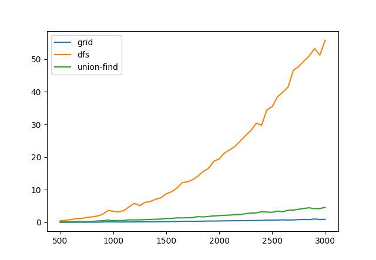

Le comportement de l'algorithme DFS lorsque le nombre de point augmente est effectivement de $O(n^2)$. C'est un algorithme très lent par rapport au deux autres. Ceci revient au fait que l'algorithme du DFS traite point par point, pour tous les points du graphe, alors que l'Union-Find permet de travailler sur des classes d'équivalences de points, et la grille restreint le domaine de recherche des voisins. En plus, la grille (grid), est effectivement une version améliorée de l'Union-Find. Il est à noter qu'on a limité le nombre de points à 3000, pour d = 0.1, puisque l'algorithme DFS prend un temps assez grand pour s'éxecuter.

### II. Effet de la distance seuil

Nous avons fixé le nombre de points pour le premier test à 1200 points à cause du temp d'exuction de l'algorithme du DFS. Pour comparer la performance des deux utilisations de la structure Union-Find, nous avons augmenter le nombre de points à 3000 et tester sur plus de valeurs de `distance`.

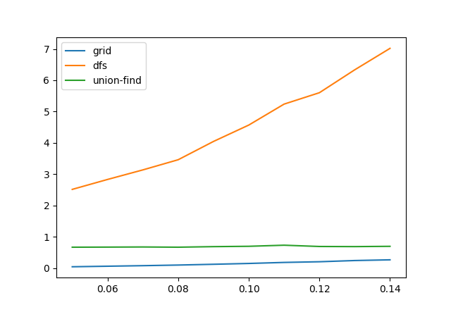

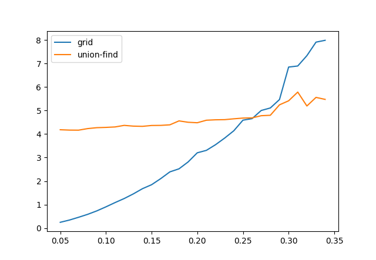

Le DFS reste toujours le moins performant. Néanmoins, on remarque que la complexité de l'union-find est approximativement constante en fonction de la distance, ce qui lui permet d'être plus performant que l'algorithme utilisant la structure grid au-delà de $\approx 0.25$. La complexité de ce dernier étant dépendante de la distance, on explique cet effet remarqué par le fait que la taille des cellules augmente, et donc le nombre de points au sein d'une même celulle augmente également. Ainsi, on augmente le nombre de points dans une cellule et ainsi le nombre de comparaisons à faire.  
Par suite, on pourrait utiliser l'algorithme grid pour un nombre de points élevé mais pour des distances inférieurs à $0.25$, et utiliser l'algorithme de Union-Find pour des distances supérieures à $0.25$.

# Pistes d'amélioration

Nous proposons un algoithme utilisant la structure grid, mais cette fois-ci sans utiliser l'algorithme de Union-Find. On utilise plutôt l'algorithme DFS pour la recherche des voisins dans les cellules adjacentes. On considère ainsi que les points au sein d'une cellule sont tous voisins, on les considère tous dans une seule composante connexe. Ainsi, chaque cellule constitue une partie connexe, et donc on ne traite plus des points mais des cellules. Ce qui nous permettrait de réduire le nombre de points à visiter.

L'idée de l'algorithme est la suivante:

1. On initialise un ensemble `visited_cells` pour suivre les cellules déjà visitées et une liste `components` pour stocker les tailles des composantes connectées.
2. On parcourt toutes les cellules de la grille. Si une cellule n'a pas encore été visitée, elle commence à explorer les composantes connectées à partir de cette cellule en utilisant une approche de recherche en profondeur (DFS) avec une pile `stack`.
3. Pendant l'exploration, elle met à jour la taille de la composante connectée en ajoutant le nombre de points de la cellule actuelle. Ensuite, elle examine les cellules adjacentes à la cellule actuelle pour vérifier si elles sont connectées à la cellule actuelle. Si une paire de points est trouvée avec une distance inférieure ou égale à la distance spécifiée, la cellule adjacente est ajoutée à la pile pour être explorée plus tard.
4. Une fois l'exploration terminée, la taille de la composante connectée est ajoutée à la liste `components`.
5. Et on itère ...

```python
def print_components_sizes(distance, points):
    grid = build_grid(distance, points)
    visited_cells = set()
    components = []
    for cell in grid:
        if cell not in visited_cells:
            stack = [cell]
            length_composante = 0
            while stack:
                curr_cell = stack.pop()
                if curr_cell not in visited_cells:
                    visited_cells.add(curr_cell)
                    adj_cells = [
                        (cell[0] + dx ,cell[1] + dy) for dx in [-1,1] for dy in [-1,1]]\
                        + [(cell[0]-1,cell[1]),(cell[0]+1,cell[1]),(cell[0],cell[1]-1),(cell[0],cell[1]+1)]\
                        + [(cell[0] + dx ,cell[1] + dy) for dx in [-2,2] for dy in [-1,0,1]]\
                        + [\
                            (cell[0]-1,cell[1]+2),\
                           (cell[0],cell[1]+2),\
                           (cell[0]+1,cell[1]+2),\
                           (cell[0]-1,cell[1]-2),\
                           (cell[0],cell[1]-2),\
                           (cell[0]+1,cell[1]-2)
                           ]
                    length_composante += len(grid[curr_cell])
                    for adj_cell in adj_cells:
                        if adj_cell in grid and adj_cell not in visited_cells:
                            marker = len(stack)
                            for idx_point in grid[curr_cell]:
                                for idx_adj_point in grid[adj_cell]:
                                    if points[idx_point].distance_to(points[idx_adj_point]) <= distance:
                                        if adj_cell not in stack:
                                            stack.append(adj_cell)
                                            break
                                if len(stack) > marker:
                                    break
            components.append(length_composante)
    components.sort(reverse=True)
    print(components)
```